# High Temperature Design Considerations for SimpleLink MSP432P4111T MCU

## 1. Introduction to Extended-Temperature MSP432™ devices

The newest members of the MSP432P4 family, the MSP432P4x11/Y/V devices, offer not only larger memories of up to 2MB of Flash and 256kB of SRAM, but also an extended-temperature capability that enables operation at 105C. The microcontrollers that have been characterized at this higher temperature are designated by a “T” suffix. Devices supporting the standard 85C temperature range are designated by an “I” suffix, as shown in the table below.

| Device | Flash | SRAM | Temperature Range |
| --- | --- | --- | --- |
| MSP432P4x11I | 2048 | 256 | -40C to 85C |
| MSP432P4x1YI | 1024 | 256 | -40C to 85C |
| MSP432P4x1VI | 512 | 128 | -40C to 85C |
| MSP432P4x11T | 2048 | 256 | -40C to 105C |
| MSP432P4x1YT | 1024 | 256 | -40C to 105C |
| MSP432P4x1VT | 512 | 128 | -40C to 105C |

In this document, the term “P401R” will be used to reference the existing MSP432P401R & MSP432P401M devices. The term “P4x11I” will refer to the 85C commercial temperature devices MSP432P4x11, MSP432P4x1Y, and MSP432P4x1X, and MSP432P4x1V. Similarly, the term “P4x11T” refers to the 105C Industrial temperature devices MSP432P4x11T, MSP432P4x1YT, and MSP432P4x1XT, and MSP432P4x1VT.

## 2. Hardware Changes for P4x11T devices

The introduction of an extended operating temperature range has the following impacts on device performance.

### 2.1 Operating Mode CPU Frequency Changes

All commercial-temperature (85C) devices in the MSP432 family have the same CPU frequency capabilities in the active mode. The extended temperature (105C) devices operate *only* on the lower core voltage VCORE0, and as a result are able to operate only up to frequencies associated with that voltage. The table below compares the maximum CPU frequency ranges for each operating mode between the P401R (256kB and smaller Flash devices), P4x11I (512kB-2MB Flash devices at 85C Industrial Temperature) and the P4x11T devices (512kB-2MB Flash devices at 105C).

|  |  | f<sub>MCLK</sub> | f<sub>MCLK</sub> | f<sub>MCLK</sub> |  |
| --- | --- | --- | --- | --- | --- |
|  |  | P401R | P4x11I | P411xT |  |
| OPERATING_MODE | DESCRIPTION | 85C | 85C | 105C | Unit |
| AM_LDO_VCORE0 | Normal performance mode with LDO as the active regulator | 24 | 24 | 24 | MHz |
| AM_LDO_VCORE1 | High performance mode with LDO as the active regulator | 48 | 48 | N/A | MHz |
| AM_DCDC_VCORE0 | Normal performance mode with DC-DC as the active regulator | 24 | 24 | 24 | MHz |
| AM_DCDC_VCORE1 | High performance mode with DC-DC as the active regulator | 48 | 48 | N/A | MHz |
| AM_LF_VCORE0 | Low-frequency mode with LDO as the active regulator | 128 | 128 | 128 | kHZ |
| AM_LF_VCORE1 | Low-frequency mode with LDO as the active regulator | 128 | 128 | N/A | kHZ |

### 2.2 Operating Mode Peripheral Frequency Changes

All peripherals in the MSP432 family operate at up to 1/2 the max CPU frequency available in active modes. The P4x11I devices have an enhanced performance capability in LPM low-power modes which allows operation of peripherals at up to 128kHz vs. 32.768kHz in the P401R devices.

The Industrial temperature (105C) devices operate only on the lower core voltage VCORE0, and as a result are able to operate only up to frequencies associated with that voltage. The VCORE1 setting should not be used with these devices.

- Operating mode Peripheral frequency (f<sub>MAX</sub>) comparison of MSP432 family devices

|  |  | f<sub>MAX</sub> | f<sub>MAX</sub> | f<sub>MAX</sub> |  |
| --- | --- | --- | --- | --- | --- |
|  |  | P401R | P4x11I | P411xT |  |
| Parameter | OPERATING MODE | 85C | 85C | 105C | Unit |
| f<sub>AM_LPM0_VCORE0</sub> |  |  |  |  |  |
|  | AM_LDO_VCORE0 | 12 | 12 | 12 | MHz |
|  | AM_DCDC_VCORE0 | 12 | 12 | 12 | MHz |
|  | LPM0_LDO_VCORE0 | 12 | 12 | 12 | MHz |
|  | LPM0_DCDC_VCORE0 | 12 | 12 | 12 | MHz |
| f<sub>AM_LPM0_VCORE1</sub> |  |  |  |  |  |
|  | AM_LDO_VCORE1 | 24 | 24 | N/A | MHz |
|  | AM_DCDC_VCORE1 | 24 | 24 | N/A | MHz |
|  | LPM0_LDO_VCORE1 | 24 | 24 | N/A | MHz |
|  | LPM0_DCDC_VCORE1 | 24 | 24 | N/A | MHz |
| f<sub>AM_LPM0_LF</sub> |  |  |  |  |  |
|  | AM_LF_VCORE0 | 128 | 128 | 128 | kHz |
|  | AM_LF_VCORE1 | 128 | 128 | 128 | kHz |
|  | LPM0_LF_VCORE0 | 128 | 128 | 128 | kHz |
|  | LPM0_LF_VCORE1 | 128 | 128 | 128 | kHz |
| f<sub>LPM3(1)</sub> |  |  |  |  |  |
|  | LPM3_VCORE0 | 32.768 | 128 | 128 | kHz |
|  | LPM3_VCORE1 | 32.768 | 128 | N/A | kHz |
| f<sub>LPM4(2)</sub> |  |  |  |  |  |
|  | LPM4_VCORE0 | N/A | 128 | 128 | kHz |
|  | LPM4_VCORE1 | N/A | 128 | N/A | kHz |
| f<sub>LPM3.5(1)</sub> |  |  |  |  |  |
|  | LPM3.5 | 32.768 | 32.768 | 32.768 | kHz |

### 2.3 Flash Wait-State Changes

- Maximum supported MCLK Freq vs. Flash Wait-states (MHz) in Normal read mode
- Reported max MCLK is for both AM_LDO and AM_DCDC active modes

|  |  | P401R | P401R | P4x11I | P4x11I |
| --- | --- | --- | --- | --- | --- |
|  |  | 85C | 85C | 85C | 85C |
| Parameter | # WAIT STATEs | VCORE0 | VCORE1 | VCORE0 | VCORE1 |
| fMAX_NRM_FLWAIT0 | 0 | 16 | 24 | 10 | 13 |
| fMAX_NRM_FLWAIT1 | 1 | 24 | 48 | 21 | 27 |
| fMAX_NRM_FLWAIT2 | 2 | NA | 12 | 24 | 40 |
| fMAX_NRM_FLWAIT3 | 3 | NA | NA | 24 | 48 |

## 3. Software Differences in ’P4x11T devices

The P4x11I (commercial temperature) and P4x11T (Industrial temperature) devices are functionally identical and the development environment will report them as having the same family IDs. However, the differences in frequency & voltage settings between the two devices requires changes in the underlying power management TI drivers when using an RTOS. (You will make the same kind of adjustments in your own code when calling Driverlib APIs). During application development, the linker must be instructed to include the correct power driver. The instructions below describe how to do this when building a TI-RTOS application from within Code Composer Studio.

- This example uses the “powerdeepsleep” MSP432P4111 example, which is available from TI resource explorer within CCS. From Resource Explorer, shown in the image below, you can find this example at the path:
- Software-> SimpleLink MSP432 SDK
- -> Examples
- -> Development Tools
- -> MSP432P4111 LaunchPad
- -> TI Drivers
- -> powerdeepsleep
- -> TI-RTOS
- -> CCS Compiler

[figure not shown]

From there you can click the CCS icon in the upper right corner to import this project into the CCS IDE. When you have done this, your CCS Project Explorer window should look something like the image below.

[figure not shown]

- Next we will modify the power management TI Drivers to link to the High-Temp library for our device and IDE. To access the project properties for this example, Right-click on the project name (powerdeepsleep_MSP_EXP432P4111_tirtos_ccs highlighted in the upper left of the image) and select “Properties”. This will open a popup window shown below.

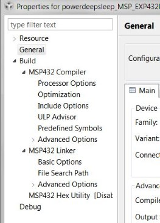

- From the Project properties popup , click on “MSP432 Linker” -> File Search Path as shown in the lower left corner of the above image. The popup will now show all of the libraries linked into the current project, as shown below. The highlighted file “drivers_msp432p4x1xi.aem4f” are the power drivers for an 85C device for the CCS IDE.

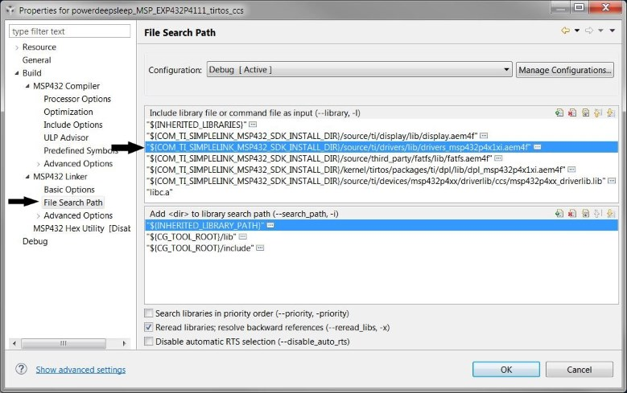

- The table below shows the available power drivers for the P401R, P4x11I (85C) and P4x11T (105C) devices. For this example, we will be selecting a driver to support the 105C device in the CCS IDE, so we will be changing the driver from drivers_msp432p4x1xi.aem4f to drivers_msp432p4x1xt.aem4f.

| File | Compiler | Device | Description |
| --- | --- | --- | --- |
| drivers_msp432p401x.aem4f | TI | MSP432P401x | Power drivers for P401R/M devices (85C) |
| drivers_msp432p401x.am4fg | GCC | MSP432P401x | Power drivers for P401R/M devices (85C) |
| drivers_msp432p401x.arm4f | IAR | MSP432P401x | Power drivers for P401R/M devices (85C) |
| drivers_msp432p4x1xi.aem4f | TI | MSP432P4x1xi | Power drivers for P4x1V/Y/1I devices (85C) |
| drivers_msp432p4x1xi.am4fg | GCC | MSP432P4x1xi | Power drivers for P4x1V/Y/1I devices (85C) |
| drivers_msp432p4x1xi.arm4f | IAR | MSP432P4x1xi | Power drivers for P4x1V/Y/1I devices (85C) |
| drivers_msp432p4x1xt.aem4f | TI | MSP432P4x1xt | Power drivers for P4x1V/Y/1T devices (105C) |
| drivers_msp432p4x1xt.am4fg | GCC | MSP432P4x1xt | Power drivers for P4x1V/Y/1T devices (105C) |
| drivers_msp432p4x1xt.arm4f | IAR | MSP432P4x1xt | Power drivers for P4x1V/Y/1T devices (105C) |

- To change this driver, select the current power driver highlighted in the figure and click the “edit” icon (red arrow). An “Edit file path” dialog will appear. Edit the line shown so that the file name reads “drivers_msp432p4x1xt.aem4f”. The rest of the file path should remain unchanged.

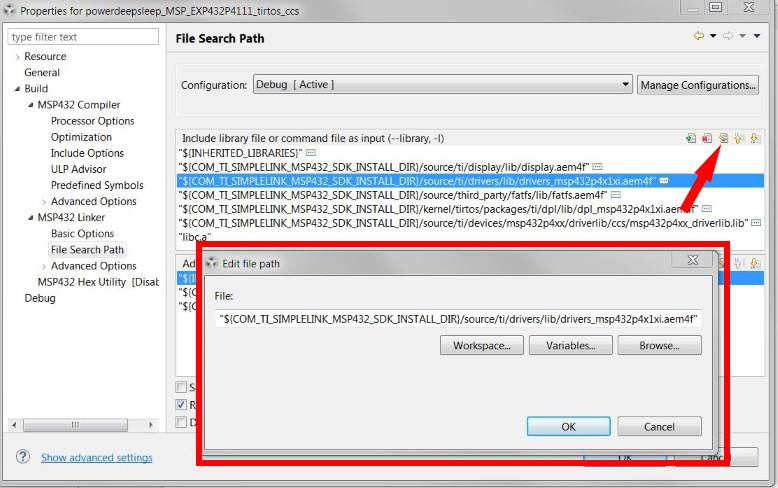

- Click “OK” on the “Edit File Path” dialog box
- Clock “OK” on the “Properties for powerdeepsleep_MSP_EXP432P4111_tirtos_ccs” dialog
- Compile the resulting program by selecting (left-click) the project name and from the menu bar click “Project-> Build Project”.

Your RTOS project is now able to operate properly on P4x11T (105C) devices!

- The TI Driver Power-Levels for the high temp device is shown below.

| Level | MCLK (MHz) | HSMCLK (MHz) | SMCLK (MHz) | ACLK (Hz) |
| --- | --- | --- | --- | --- |
| 0 | 6 | 3 | 3 | 32768 |
| 1 | 12 | 12 | 6 | 32768 |
| 2 | 24 | 24 | 12 | 32768 |

Please note that these values are different from the default MSP432P4x11I device. Power_Management provides more details for TI Power driver handling.